# Q4

```python
import os
import re
import numpy as np
import tensorflow as tf
from tensorflow.keras.callbacks import EarlyStopping
from sklearn.model_selection import train_test_split
from sklearn.metrics import accuracy_score, f1_score, confusion_matrix
from matplotlib import pyplot as plt
```

```python
def extract_race(file_name):
    match = re.match(r"\d+_\d+_(\d+)_\d+\.jpg\.chip", file_name)
    if match:
        race = int(match.group(1))
        return race
    else:
        return None

def extract_gender(file_name):
    # Extract gender information using regular expressions
    pattern = r'_(\d)_'
    match = re.search(pattern, file_name)
    if match:
        return int(match.group(1))
    else:
        return None
```

```python
folder_path = "Face_Data/crop_part1/"
file_paths = []
labels = []
gender_labels, male_index, female_index = [], [], []
for index, file_name in enumerate(os.listdir(folder_path)):
    if file_name.endswith(".jpg.chip.jpg"):
        file_path = os.path.join(folder_path, file_name)
        race = extract_race(file_name)
        gender = extract_gender(file_name)
        if race is not None and gender is not None:
            file_paths.append(file_path)
            labels.append(race)
            gender_labels.append(gender)
            if gender == 0:
                male_index.append(index)
            else:
                female_index.append(index)
```

```python
num_classes = np.unique(labels).shape[0]
X_train, X_test, y_train, y_test = train_test_split(file_paths, labels, test_size=0.2, random_state=42)
X_train, X_val, y_train, y_val = train_test_split(X_train, y_train, test_size=0.2, random_state=42)
```

```python
def preprocess_image(file_path):
    # Load and preprocess the image
    image = tf.io.read_file(file_path)
    image = tf.image.decode_jpeg(image, channels=3)
    image = tf.image.resize(image, [224, 224])  # Adjust the image size as needed
    image = image / 255.0  # Normalize the pixel values to the range [0, 1]
    return image
```

```python
# Preprocess the image file paths
X_train = [preprocess_image(file_path) for file_path in X_train]
X_val = [preprocess_image(file_path) for file_path in X_val]
X_test = [preprocess_image(file_path) for file_path in X_test]
```

```
Metal device set to: Apple M1 Pro

systemMemory: 16.00 GB
maxCacheSize: 5.33 GB
```

```python
model = tf.keras.Sequential([
    tf.keras.applications.MobileNetV2(input_shape=(224, 224, 3), include_top=False),
    tf.keras.layers.GlobalAveragePooling2D(),
    tf.keras.layers.Dense(256, activation='relu'),
    tf.keras.layers.Dropout(0.5),
    tf.keras.layers.Dense(128, activation='relu'),
    tf.keras.layers.Dropout(0.5),
    tf.keras.layers.Dense(num_classes, activation='softmax')
])
```

MobileNetV2: The MobileNetV2 layer is used as the base convolutional neural network (CNN) model. It is a lightweight and efficient CNN architecture that has been pre-trained on a large dataset (ImageNet). By including this layer, your model can leverage the powerful feature extraction capabilities learned from ImageNet. It can help us to extract details form the face picture data.

Based on the pretrained layers, we add some more layers.

GlobalAveragePooling2D: This layer reduces the spatial dimensions of the input features from the previous layer. It computes the average value for each feature map, resulting in a fixed-length vector that summarizes the important features of the input.

Dense: The first Dense layer consists of 256 neurons and uses the ReLU activation function. It introduces non-linearity to the model and allows for learning complex patterns in the data.

Dropout: The first Dropout layer is added after the first Dense layer. It randomly sets a fraction of input units to 0 during training, which helps prevent overfitting by providing regularization and reducing the reliance on specific features.

Dense: The second Dense layer consists of 128 neurons and also uses the ReLU activation function. It further enhances the model's capacity to learn intricate patterns and relationships in the data.

Dropout: The second Dropout layer is added after the second Dense layer. It serves the same purpose as the first Dropout layer by reducing overfitting and improving generalization.

Dense: The final Dense layer consists of 5 neural corresponding to the 5 different classes of outputs. They have an activation function of softmax.

```python
early_stopping = EarlyStopping(monitor='val_loss', patience=3, verbose=1)

model.compile(optimizer='adam',
              loss=tf.keras.losses.SparseCategoricalCrossentropy(from_logits=False),
              metrics=['accuracy'])

early_stopping = EarlyStopping(monitor='val_loss', patience=3, verbose=1)

batch_size = 32
epochs = 25

history = model.fit(
    tf.convert_to_tensor(X_train),
    tf.convert_to_tensor(y_train),
    batch_size=batch_size,
    epochs=epochs,
    validation_data=(tf.convert_to_tensor(X_val), tf.convert_to_tensor(y_val)),
    callbacks=[early_stopping]
)
```

```
2023-05-12 16:30:06.789108: W tensorflow/tsl/platform/profile_utils/cpu_utils.cc:128] Failed to get CPU frequency: 0 Hz
```

[output not shown]

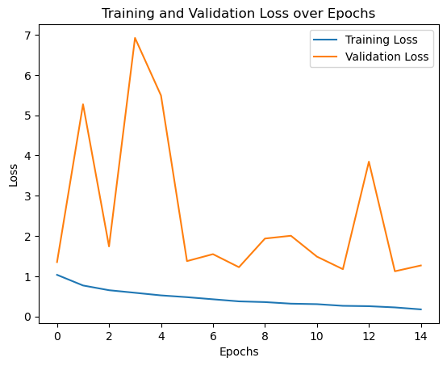

```
Test Loss: 1.2854477167129517
Test Accuracy: 0.6871165633201599
```

[figure not shown]

```
Test Loss: 1.2854477167129517
Test Accuracy: 0.6871165633201599
```

```python
test_loss, test_acc = model.evaluate(tf.convert_to_tensor(X_test), tf.convert_to_tensor(y_test))

# Plot the training and validation loss over epochs
plt.plot(history.history['loss'], label='Training Loss')
plt.plot(history.history['val_loss'], label='Validation Loss')
plt.xlabel('Epochs')
plt.ylabel('Loss')
plt.title('Training and Validation Loss over Epochs')
plt.legend()
plt.show()

# Evaluate the model on the test set
print('Test Loss:', test_loss)
print('Test Accuracy:', test_acc)

# Plot the training and validation loss over epochs
plt.plot(history.history['val_accuracy'], label='validation')
plt.plot(history.history['accuracy'], label='training')
plt.xlabel('Epochs')
plt.ylabel('Loss')
plt.title('Accuracy over Epochs')
plt.legend()
plt.show()

# Evaluate the model on the test set
print('Test Loss:', test_loss)
print('Test Accuracy:', test_acc)
```

```python
X_test_tensor = tf.convert_to_tensor(X_test)
y_pred = model.predict(X_test_tensor)
predicted_classes = tf.argmax(y_pred, axis=1)
# Print the predicted values
print(predicted_classes)
```

```
tf.Tensor([3 3 0 ... 0 0 0], shape=(1956,), dtype=int64)
```

```python
# Calculate accuracy
accuracy = accuracy_score(y_test, predicted_classes)
print(f'Accuracy: {accuracy}')

# Calculate F1 score
f1 = f1_score(y_test, predicted_classes, average='weighted')
print(f'F1 Score: {f1}')

# Calculate confusion matrix
cm = confusion_matrix(y_test, predicted_classes)
print('Confusion Matrix:')
print(cm)
```

```
Accuracy: 0.6871165644171779
F1 Score: 0.6604845868248015
Confusion Matrix:
[[906   3  25 130   4]
 [ 11  15   8  45   2]
 [ 63   2 168  72   2]
 [ 37   3   5 244   3]
 [ 86   1  16  94  11]]
```

# Fairness and Bias

```python
y_test_male = [x for i, x in enumerate(y_test) if i in male_index]
y_test_female = [x for i, x in enumerate(y_test) if i in female_index]
predicted_classes_male = [x for i, x in enumerate(predicted_classes) if i in male_index]
predicted_classes_female = [x for i, x in enumerate(predicted_classes) if i in female_index]

accuracy_priv = accuracy_score(y_test_male, predicted_classes_male)
print("Accuracy for male:", accuracy)
accuracy_unpriv = accuracy_score(y_test_female, predicted_classes_female)
print("Accuracy for female:", accuracy)
disparate_score = accuracy_priv/accuracy_unpriv
print("disparate_score:", disparate_score)
```

```
Accuracy for male: 0.6871165644171779
Accuracy for female: 0.6871165644171779
disparate_score: 1.0099022317177957
```